# 20분만에 끝내는 딥러닝

딥러닝 모형 개발 자동화

[한국 R 사용자회](https://r2bit.com/)

# 1 6단계 autoML

[Bojan Tunguz (Jan 23, 2020), “Six Levels of Auto ML”, medium.com](https://medium.com/@tunguz/six-levels-of-auto-ml-a277aa1f0f38)

**자율주행**

- Level 0: Automated system issues warnings and may momentarily intervene but has no sustained vehicle control.
- Level 1 (“hands on”): The driver and the automated system share control of the vehicle. Examples are Adaptive Cruise Control and Parking Assistance
- Level 2 (“hands off”): The automated system takes full control of the vehicle (accelerating, braking, and steering).
- Level 3 (“eyes off”): The driver can safely turn their attention away from the driving tasks, e.g. the driver can text or watch a movie.
- Level 4 (“mind off”): As level 3, but no driver attention is ever required for safety, e.g. the driver may safely go to sleep or leave the driver’s seat.
- Level 5 (“steering wheel optional”): No human intervention is required at all. An example would be a robotic taxi.

**autoML**

Level 0: No automation. You code your own ML algorithms. From scratch. In C++.

Level 1: Use of high-level algorithm APIs. Sklearn, Keras, Pandas, H2O, XGBoost, etc.

Level 2: Automatic hyperparameter tuning and ensembling. Basic model selection.

Level 3: Automatic (technical) feature engineering and feature selection, technical data augmentation, GUI.

Level 4: Automatic domain and problem specific feature engineering, data augmentation, and data integration.

Level 5: Full ML Automation. Ability to come up with super-human strategies for solving hard ML problems without any input or guidance. Fully conversational interaction with the human user.

## 1.1 MLOps

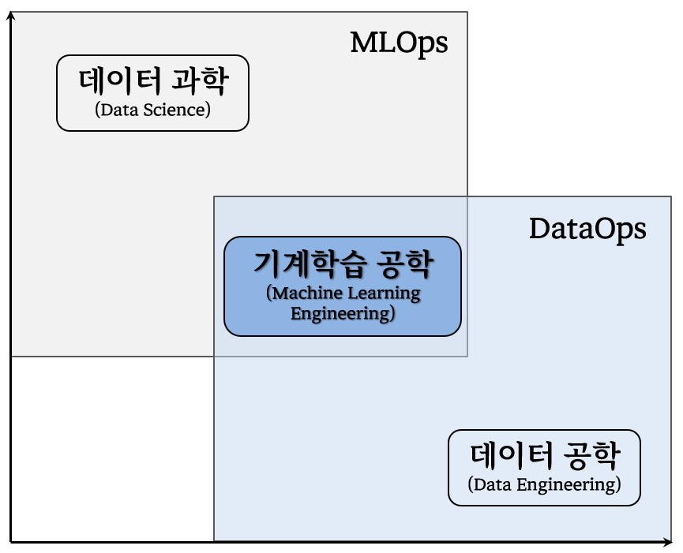

- **MLOPS** 25% 규칙
  - 데이터 25%
  - 비즈니스 25%
  - 모형 25%
  - DevOps 25%

## 1.2 모형 공장

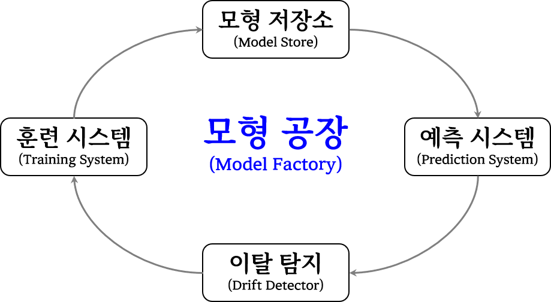

## 1.3 개념과 데이터 Drift

- Concept Drift
- Label Drift
- Feature Drift

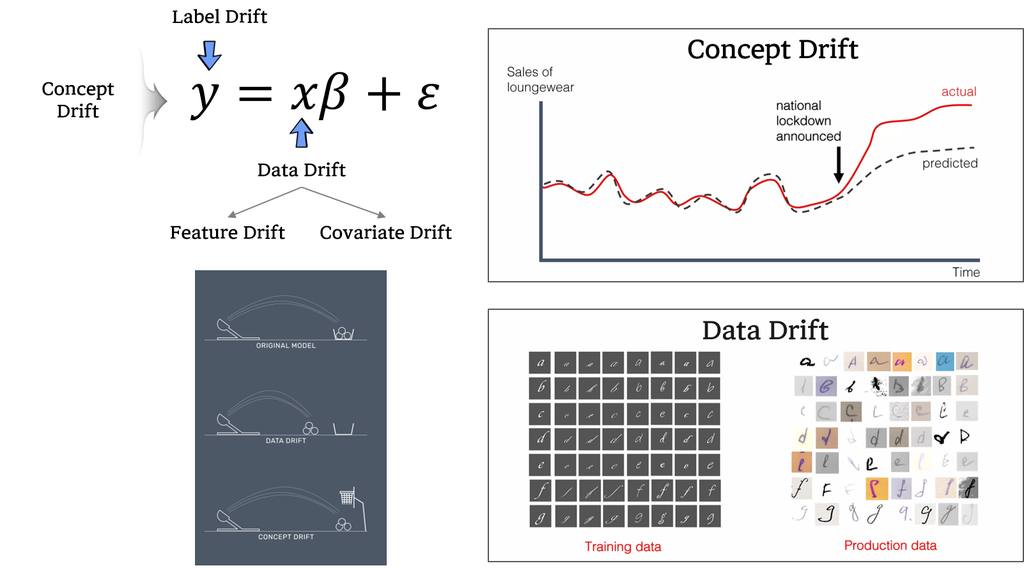

- https://www.fiddler.ai/blog/drift-in-machine-learning-how-to-identify-issues-before-you-have-a-problem
- https://twitter.com/kdimensions1/status/1442096041201844228?s=20&t=hPl7rxBTrdpqNE5T9lqO7w
- https://www.youtube.com/watch?v=q_shb4Lyqg0

## 1.4 Drift 유형

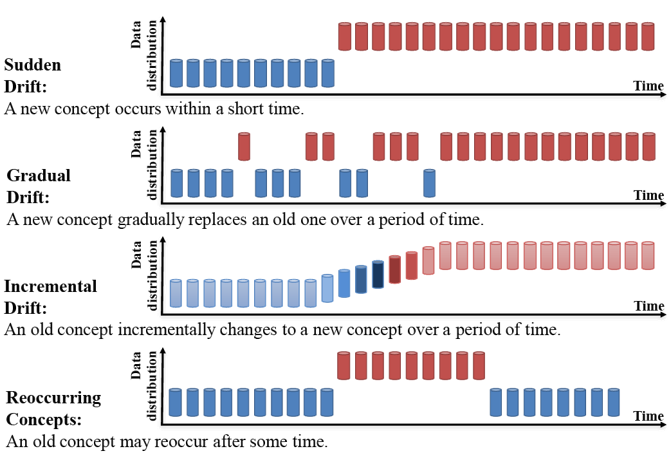

## 1.5 Drift 탐지

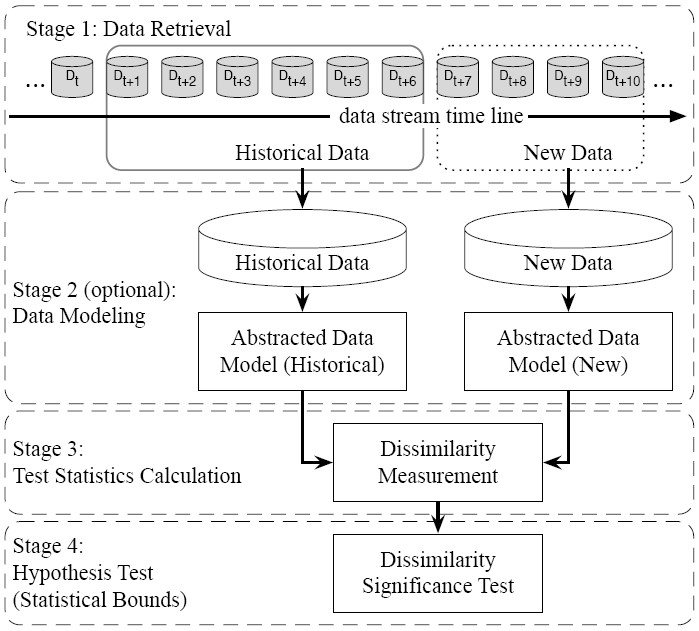

Lu, Jie, et al. “Learning under concept drift: A review.” IEEE Transactions on Knowledge and Data Engineering 31.12 (2018): 2346-2363. [다운로드](https://arxiv.org/pdf/2004.05785.pdf)

# 2 AutoKeras

[AutoKeras](https://autokeras.com/)는 Texas A&M 대학에서 개발한 Keras 에 기반한 AutoML 시스템이다. AutoKeras 의 목표는 모든 사람에게 기계학습을 쉽게 할 수 있게 하는 것으로 일종의 기계학습 민주화 운동으로 볼 수 있다.

Luis Sobrecueva (May 21, 2021), “Automated Machine Learning with AutoKeras: Deep learning made accessible for everyone with just few lines of coding”, Packt Publishing

## 2.1 설치

```
pip install git+https://github.com/keras-team/keras-tuner.git
pip install autokeras
```

```python
import numpy as np
import tensorflow as tf
from tensorflow.keras.datasets import mnist
from tensorflow.python.keras.utils.data_utils import Sequence
import autokeras as ak

###### GPU 활성화 코드 ##############
os.environ["TF_CPP_MIN_LOG_LEVEL"] = "2"
config = tf.compat.v1.ConfigProto(log_device_placement=True)
config.gpu_options.allow_growth = True
sess = tf.compat.v1.Session(config=config)
#####################################

(x_train, y_train), (x_test, y_test) = mnist.load_data()
print(x_train.shape)  # (60000, 28, 28)
print(y_train.shape)  # (60000,)
print(y_train[:3])  # array([7, 2, 1], dtype=uint8)


# Initialize the image classifier.
clf = ak.ImageClassifier(overwrite=True,
                         max_trials=1,
                         distribution_strategy=tf.distribute.MirroredStrategy())
# Feed the image classifier with training data.
clf.fit(x_train,
        y_train,
        # Split the training data and use the last 15% as validation data.
        validation_split=0.15,
        epochs=5)
# Predict with the best model.
predicted_y = clf.predict(x_test)
print(predicted_y)

#   1/313 [..............................] - ETA: 6:49
#  16/313 [>.............................] - ETA: 1s
#  24/313 [=>............................] - ETA: 1s
#  38/313 [==>...........................] - ETA: 1s
#  53/313 [====>.........................] - ETA: 1s
#  68/313 [=====>........................] - ETA: 1s
#  80/313 [======>.......................] - ETA: 1s
#  89/313 [=======>......................] - ETA: 1s
# 103/313 [========>.....................] - ETA: 0s
# 112/313 [=========>....................] - ETA: 0s
# 125/313 [==========>...................] - ETA: 0s
# 138/313 [============>.................] - ETA: 0s
# 151/313 [=============>................] - ETA: 0s
# 155/313 [=============>................] - ETA: 0s
# 159/313 [==============>...............] - ETA: 0s
# 171/313 [===============>..............] - ETA: 0s
# 186/313 [================>.............] - ETA: 0s
# 194/313 [=================>............] - ETA: 0s
# 209/313 [===================>..........] - ETA: 0s
# 222/313 [====================>.........] - ETA: 0s
# 237/313 [=====================>........] - ETA: 0s
# 246/313 [======================>.......] - ETA: 0s
# 259/313 [=======================>......] - ETA: 0s
# 272/313 [=========================>....] - ETA: 0s
# 285/313 [==========================>...] - ETA: 0s
# 288/313 [==========================>...] - ETA: 0s
# 301/313 [===========================>..] - ETA: 0s
# 313/313 [==============================] - ETA: 0s
# 313/313 [==============================] - 3s 5ms/step
#
#   1/313 [..............................] - ETA: 29s
#   6/313 [..............................] - ETA: 3s
#  20/313 [>.............................] - ETA: 1s
#  33/313 [==>...........................] - ETA: 1s
#  45/313 [===>..........................] - ETA: 1s
#  49/313 [===>..........................] - ETA: 1s
#  61/313 [====>.........................] - ETA: 1s
#  76/313 [======>.......................] - ETA: 1s
#  92/313 [=======>......................] - ETA: 1s
# 101/313 [========>.....................] - ETA: 1s
# 117/313 [==========>...................] - ETA: 0s
# 132/313 [===========>..................] - ETA: 0s
# 142/313 [============>.................] - ETA: 0s
# 149/313 [=============>................] - ETA: 0s
# 163/313 [==============>...............] - ETA: 0s
# 177/313 [===============>..............] - ETA: 0s
# 187/313 [================>.............] - ETA: 0s
# 193/313 [=================>............] - ETA: 0s
# 208/313 [==================>...........] - ETA: 0s
# 223/313 [====================>.........] - ETA: 0s
# 232/313 [=====================>........] - ETA: 0s
# 240/313 [======================>.......] - ETA: 0s
# 255/313 [=======================>......] - ETA: 0s
# 269/313 [========================>.....] - ETA: 0s
# 283/313 [==========================>...] - ETA: 0s
# 292/313 [==========================>...] - ETA: 0s
# 306/313 [============================>.] - ETA: 0s
# 313/313 [==============================] - 1s 4ms/step
# >>> print(predicted_y)
# [['7']
#  ['2']
#  ['1']
#  ...
#  ['4']
#  ['5']
#  ['6']]
# Evaluate the best model with testing data.

print(clf.evaluate(x_test, y_test))

#   1/313 [..............................] - ETA: 1:53 - loss: 0.0070 - accuracy: 1.0000
#   9/313 [..............................] - ETA: 2s - loss: 0.0132 - accuracy: 0.9965
#  14/313 [>.............................] - ETA: 2s - loss: 0.0262 - accuracy: 0.9911
#  19/313 [>.............................] - ETA: 2s - loss: 0.0245 - accuracy: 0.9901
#  24/313 [=>............................] - ETA: 2s - loss: 0.0259 - accuracy: 0.9883
#  33/313 [==>...........................] - ETA: 2s - loss: 0.0433 - accuracy: 0.9839
#  38/313 [==>...........................] - ETA: 2s - loss: 0.0437 - accuracy: 0.9844
#  46/313 [===>..........................] - ETA: 2s - loss: 0.0526 - accuracy: 0.9810
#  55/313 [====>.........................] - ETA: 2s - loss: 0.0545 - accuracy: 0.9807
#  64/313 [=====>........................] - ETA: 1s - loss: 0.0542 - accuracy: 0.9814
#  69/313 [=====>........................] - ETA: 1s - loss: 0.0599 - accuracy: 0.9805
#  75/313 [======>.......................] - ETA: 1s - loss: 0.0585 - accuracy: 0.9808
#  84/313 [=======>......................] - ETA: 1s - loss: 0.0589 - accuracy: 0.9807
#  93/313 [=======>......................] - ETA: 1s - loss: 0.0588 - accuracy: 0.9802
#  99/313 [========>.....................] - ETA: 1s - loss: 0.0576 - accuracy: 0.9804
# 107/313 [=========>....................] - ETA: 1s - loss: 0.0553 - accuracy: 0.9813
# 115/313 [==========>...................] - ETA: 1s - loss: 0.0556 - accuracy: 0.9818
# 123/313 [==========>...................] - ETA: 1s - loss: 0.0561 - accuracy: 0.9817
# 128/313 [===========>..................] - ETA: 1s - loss: 0.0552 - accuracy: 0.9819
# 137/313 [============>.................] - ETA: 1s - loss: 0.0541 - accuracy: 0.9822
# 145/313 [============>.................] - ETA: 1s - loss: 0.0536 - accuracy: 0.9823
# 153/313 [=============>................] - ETA: 1s - loss: 0.0541 - accuracy: 0.9820
# 155/313 [=============>................] - ETA: 1s - loss: 0.0538 - accuracy: 0.9821
# 163/313 [==============>...............] - ETA: 1s - loss: 0.0513 - accuracy: 0.9829
# 171/313 [===============>..............] - ETA: 1s - loss: 0.0492 - accuracy: 0.9836
# 178/313 [================>.............] - ETA: 1s - loss: 0.0474 - accuracy: 0.9842
# 180/313 [================>.............] - ETA: 1s - loss: 0.0474 - accuracy: 0.9842
# 188/313 [=================>............] - ETA: 0s - loss: 0.0460 - accuracy: 0.9845
# 197/313 [=================>............] - ETA: 0s - loss: 0.0446 - accuracy: 0.9849
# 204/313 [==================>...........] - ETA: 0s - loss: 0.0431 - accuracy: 0.9854
# 212/313 [===================>..........] - ETA: 0s - loss: 0.0440 - accuracy: 0.9851
# 220/313 [====================>.........] - ETA: 0s - loss: 0.0425 - accuracy: 0.9857
# 228/313 [====================>.........] - ETA: 0s - loss: 0.0410 - accuracy: 0.9862
# 234/313 [=====================>........] - ETA: 0s - loss: 0.0400 - accuracy: 0.9865
# 242/313 [======================>.......] - ETA: 0s - loss: 0.0387 - accuracy: 0.9870
# 251/313 [=======================>......] - ETA: 0s - loss: 0.0375 - accuracy: 0.9874
# 254/313 [=======================>......] - ETA: 0s - loss: 0.0378 - accuracy: 0.9873
# 257/313 [=======================>......] - ETA: 0s - loss: 0.0374 - accuracy: 0.9875
# 265/313 [========================>.....] - ETA: 0s - loss: 0.0365 - accuracy: 0.9877
# 273/313 [=========================>....] - ETA: 0s - loss: 0.0355 - accuracy: 0.9881
# 278/313 [=========================>....] - ETA: 0s - loss: 0.0348 - accuracy: 0.9883
# 283/313 [==========================>...] - ETA: 0s - loss: 0.0355 - accuracy: 0.9882
# 291/313 [==========================>...] - ETA: 0s - loss: 0.0346 - accuracy: 0.9885
# 299/313 [===========================>..] - ETA: 0s - loss: 0.0339 - accuracy: 0.9887
# 307/313 [============================>.] - ETA: 0s - loss: 0.0362 - accuracy: 0.9879
# 312/313 [============================>.] - ETA: 0s - loss: 0.0362 - accuracy: 0.9879
# 313/313 [==============================] - 3s 8ms/step - loss: 0.0362 - accuracy: 0.9879
# [0.0361783429980278, 0.9879000186920166]
```

## 2.2 모형 저장

```
mnist_auto_model = clf.export_model()

mnist_auto_model.save("data/mnist_auto_model.h5")
```

## 2.3 Inference

```python
from tensorflow.keras.models import load_model
mnist_inference_model = load_model("data/mnist_auto_model.h5")

print(mnist_inference_model.predict(x_test[:10]))

# 1/1 [==============================] - ETA: 0s
# 1/1 [==============================] - 3s 3s/step
# [[1.32050326e-09 5.58818547e-10 3.78649474e-07 9.99164172e-07
#   1.33203268e-10 2.78588975e-11 5.63584436e-16 9.99998569e-01
#   3.92891764e-09 2.32371775e-08]
#  [3.08622106e-07 4.29323836e-06 9.99992967e-01 2.70977765e-08
#   1.83834836e-09 4.31682412e-10 1.94188556e-06 6.18551694e-12
#   5.03049534e-07 3.12175737e-11]
#  [7.60133787e-08 9.99809682e-01 1.49333109e-05 2.55621785e-07
#   1.34683374e-04 2.41513249e-06 2.98452250e-07 2.57335432e-05
#   1.18708749e-05 3.97069293e-08]
#  [9.99997616e-01 3.81995867e-12 8.80706295e-07 2.07579753e-09
#   6.43973819e-10 2.07098960e-08 1.32341120e-06 1.70947601e-09
#   1.69439502e-08 2.69762097e-07]
#  [3.89613888e-08 1.29475808e-09 1.52856661e-08 1.29996272e-08
#   9.99991417e-01 2.09018178e-10 5.77958437e-09 1.13876794e-07
#   3.00419210e-08 8.33169815e-06]
#  [5.08510603e-08 9.99519467e-01 9.68662516e-06 5.38548832e-08
#   1.75294699e-04 2.23298940e-07 1.94389855e-08 2.77489919e-04
#   1.75310124e-05 1.79468174e-07]
#  [6.19284788e-12 2.30456476e-06 1.10171030e-07 3.57055230e-09
#   9.99865294e-01 5.86728781e-08 3.17030707e-11 4.35810307e-06
#   1.24242419e-04 3.70814996e-06]
#  [9.81296034e-12 7.29698924e-09 1.23314339e-06 1.13969929e-06
#   1.19719491e-03 6.22080261e-05 2.93067370e-09 3.59439731e-08
#   6.32558251e-03 9.92412508e-01]
#  [1.11055797e-05 3.99178468e-11 8.96933550e-09 7.30776932e-08
#   8.18820172e-06 9.72040772e-01 2.64719762e-02 5.06327380e-09
#   1.46416645e-03 3.62182686e-06]
#  [4.99363679e-08 2.78283840e-10 1.06951381e-08 4.76083045e-07
#   1.60303130e-03 4.39877361e-08 5.24907071e-12 8.03113682e-04
#   1.69744788e-04 9.97423530e-01]]
```

## 2.4 모형 시각화

```python
from tensorflow.keras.utils import plot_model
plot_model(mnist_inference_model,
           show_shapes=True,
           show_layer_names=True,
           to_file='assets/automation/mnist_autokeras.png')
```

[output not shown]